# Testing affect regulation via computational modeling of real-time alcohol choices in daily life: Choice Proportion

2026-04-26

# 1 About This Report

This report presents results for **Choice Proportion** (choice_prop) across all four focal predictors: stress (binary), stress (state), negative affect (state), and positive affect (state).

For each predictor, the report is organized as follows:

- **Dimensionality reduction:** PCA and UMAP component composition tables, showing which raw variables load most strongly onto each component.
- **GLMM results (raw features):** Summary of results from GLMM model with raw variables.
- **Random forest results (raw features):** Summary of results from random forest model with raw variables.
- **Model comparison:** RMSE comparison table across all methods (GLMM, random forest, decision tree) and feature sets (raw, PCA, UMAP).

# 2 Stress Binary (stress_binary)

## 2.1 Dimensionality Reduction

- **PCA components (80% variance, max 5):** 5
- **UMAP components (matching PCA):** 5

### 2.1.1 PCA Component Composition (top 5 correlated variables)

**PC_1**

| Variable | Correlation |
| --- | --- |
| alc_exp_energeticYes | -0.576 |
| alc_exp_better_moodYes | -0.557 |
| alc_exp_sociableYes | -0.547 |
| alc_exp_buzzYes | -0.502 |
| alc_craving | -0.487 |

**PC_2**

| Variable | Correlation |
| --- | --- |
| alc_exp_injuryYes | -0.596 |
| alc_exp_be_rudeYes | -0.594 |
| alc_exp_embarrassedYes | -0.579 |
| alc_exp_nauseous_vomitYes | -0.491 |
| alc_exp_hangoverYes | -0.468 |

**PC_3**

| Variable | Correlation |
| --- | --- |
| locationschool_work | 0.591 |
| alc_today | -0.578 |
| alc_cuenone | 0.568 |
| time_of_dayevening | -0.476 |
| locationhome | -0.458 |

**PC_4**

| Variable | Correlation |
| --- | --- |
| soft_yday | 0.699 |
| soft_today | 0.650 |
| soft_intend | 0.634 |
| soft_craving | 0.489 |
| alc_exp_embarrassedYes | -0.388 |

**PC_5**

| Variable | Correlation |
| --- | --- |
| locationhome | -0.632 |
| social_context_aloneYes | -0.560 |
| social_context_friend_roommateYes | 0.500 |
| social_context_strangerYes | 0.417 |
| locationsomeone_elses_home | 0.372 |

### 2.1.2 UMAP Component Composition (top 5 correlated variables)

**UMAP_1**

| Variable | Correlation |
| --- | --- |
| alc_exp_embarrassedYes | 0.297 |
| alc_exp_be_rudeYes | 0.293 |
| alc_craving | 0.220 |
| alc_intend | 0.187 |
| alc_yday | 0.172 |

**UMAP_2**

| Variable | Correlation |
| --- | --- |
| alc_yday | -0.280 |
| alc_exp_embarrassedYes | 0.172 |
| alc_exp_be_rudeYes | 0.168 |
| soft_yday | 0.120 |
| alc_mot_enhanceYes | -0.114 |

**UMAP_3**

| Variable | Correlation |
| --- | --- |
| alc_yday | 0.402 |
| alc_today | 0.394 |
| alc_cuenone | -0.164 |
| alc_intend | 0.142 |
| alc_exp_be_rudeYes | -0.136 |

**UMAP_4**

| Variable | Correlation |
| --- | --- |
| soft_yday | -0.794 |
| soft_today | -0.677 |
| soft_intend | -0.572 |
| soft_craving | -0.304 |
| alc_exp_injuryYes | -0.194 |

**UMAP_5**

| Variable | Correlation |
| --- | --- |
| alc_exp_injuryYes | -0.516 |
| alc_exp_embarrassedYes | -0.379 |
| alc_exp_be_rudeYes | -0.377 |
| alc_exp_nauseous_vomitYes | -0.360 |
| alc_exp_energeticYes | -0.229 |

## 2.2 GLMM Results

### 2.2.1 Raw Features

- **Optimal lambda:** 25 (index 16 of 21)
- **CV RMSE:** 0.2872

**Non-zero coefficients** (focal predictor terms highlighted):

| Term | Estimate | Category |
| --- | --- | --- |
| (Intercept) | 0.2627 | Intercept |
| stress_binary | 0.0012 | Focal predictor |
| alc_exp_nauseous_vomitYes | -0.0597 | Covariate main effect |
| alc_cuenone | -0.0388 | Covariate main effect |
| alc_craving | 0.0385 | Covariate main effect |
| social_context_otherYes | -0.0354 | Covariate main effect |
| alc_exp_relaxedYes | 0.0342 | Covariate main effect |
| time_of_dayevening | 0.0256 | Covariate main effect |
| alc_mot_enhanceYes | 0.0220 | Covariate main effect |
| social_context_strangerYes | 0.0174 | Covariate main effect |
| locationother | 0.0168 | Covariate main effect |
| social_context_romantic_partnerYes | 0.0160 | Covariate main effect |
| alc_exp_injuryYes | -0.0157 | Covariate main effect |
| alc_exp_be_rudeYes | -0.0154 | Covariate main effect |
| alc_exp_buzzYes | 0.0151 | Covariate main effect |
| alc_intend | 0.0148 | Covariate main effect |
| social_context_familyYes | -0.0137 | Covariate main effect |
| locationrestaurant_cafe | 0.0132 | Covariate main effect |
| alc_exp_better_moodYes | 0.0129 | Covariate main effect |
| soft_craving | -0.0118 | Covariate main effect |
| alc_exp_embarrassedYes | -0.0116 | Covariate main effect |
| alc_today | 0.0110 | Covariate main effect |
| soft_intend | -0.0106 | Covariate main effect |
| alc_exp_hangoverYes | -0.0078 | Covariate main effect |
| social_context_coworker_classmateYes | -0.0072 | Covariate main effect |
| bored_state | 0.0047 | Covariate main effect |
| alc_yday | 0.0033 | Covariate main effect |
| soft_yday | -0.0032 | Covariate main effect |
| thirst_state | 0.0025 | Covariate main effect |
| alc_mot_copingYes | 0.0023 | Covariate main effect |

[output cut: 56 more lines]

- 12 coefficients penalized to zero.*

#### 2.2.1.1 Predicted vs. Observed

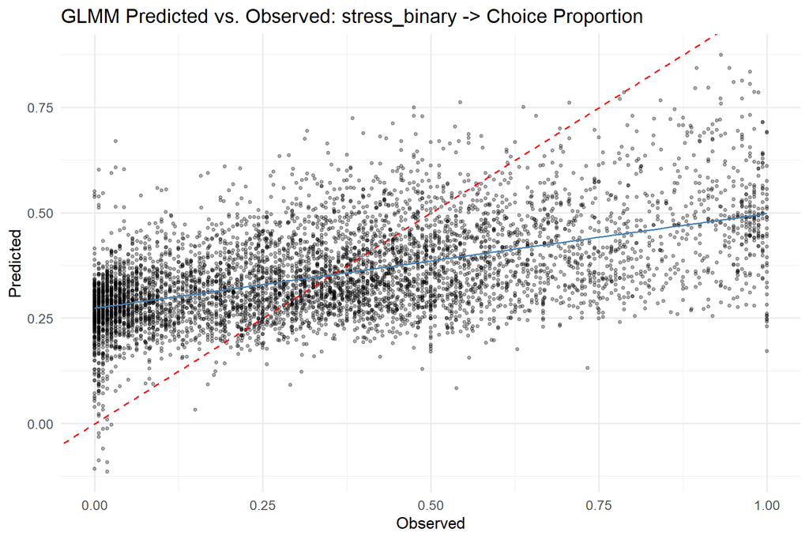

#### 2.2.1.2 Residual Diagnostics

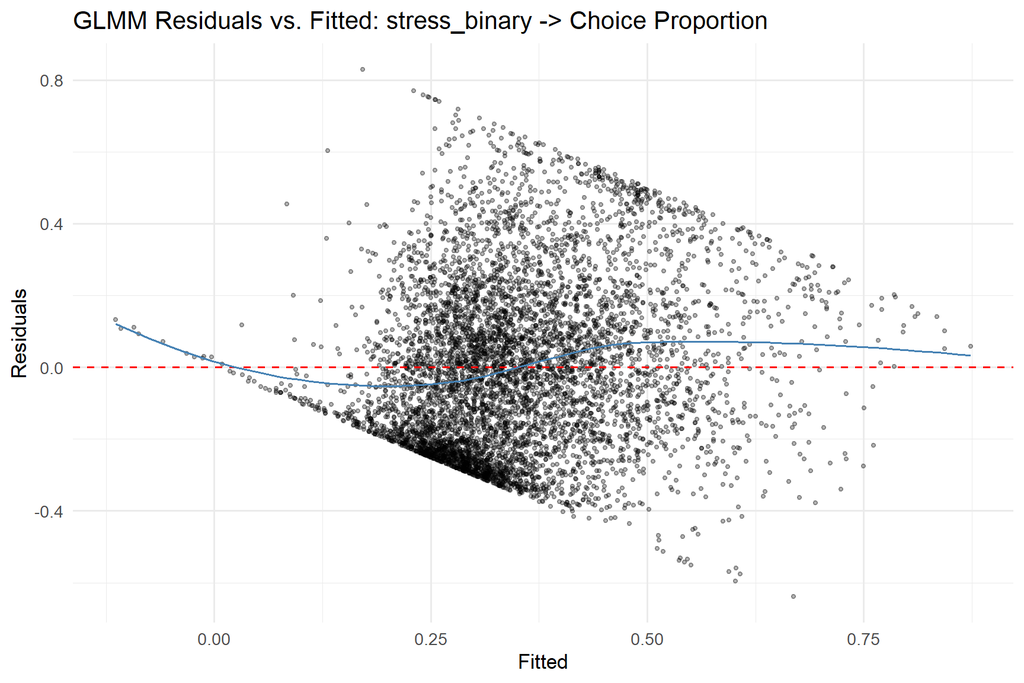

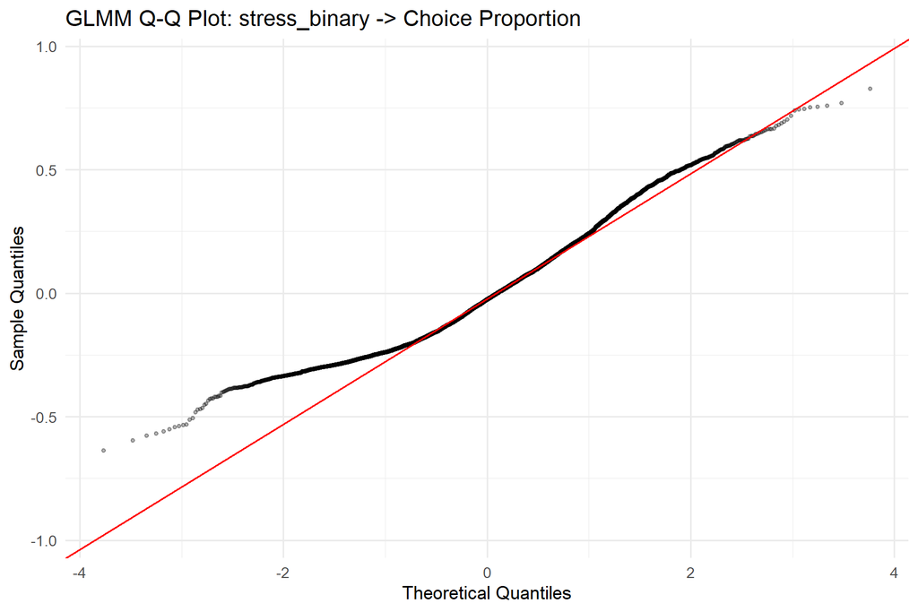

### 2.2.2 PCA Features

- **Optimal lambda:** 75 (index 6 of 21)
- **CV RMSE:** 0.3153

**Non-zero coefficients:**

| Term | Estimate |
| --- | --- |
| (Intercept) | 0.3423 |
| PC_1 | -0.0291 |
| PC_2 | 0.0600 |
| PC_3 | -0.0557 |
| stress_binary | 0.0391 |
| PC_1:stress_binary | -0.0205 |
| PC_2:stress_binary | 0.0167 |
| PC_3:stress_binary | -0.0047 |
| PC_5:stress_binary | -0.0305 |

- 3 coefficients penalized to zero.*

### 2.2.3 UMAP Features

- **Optimal lambda:** 100 (index 1 of 21)
- **CV RMSE:** 0.2896

**Non-zero coefficients:**

| Term | Estimate |
| --- | --- |
| (Intercept) | 0.3401 |
| UMAP_2 | -0.0050 |
| UMAP_3 | 0.0113 |
| UMAP_4 | 0.0301 |
| stress_binary | 0.0661 |
| UMAP_4:stress_binary | 0.0043 |
| UMAP_5:stress_binary | 0.0127 |

- 5 coefficients penalized to zero.*

## 2.3 Random Forest Results (Raw)

### 2.3.1 Tuning Summary

- **mtry:** 14
- **min.node.size:** 2
- **sample.fraction:** 0.786
- **CV RMSE:** 0.193

### 2.3.2 Variable Importance (Permutation)

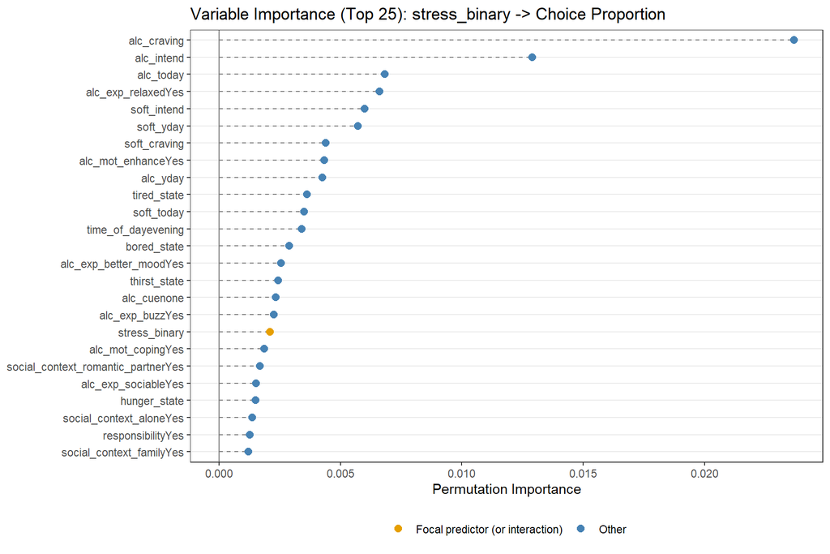

**Full importance ranking:**

| Variable | Importance |
| --- | --- |
| alc_craving | 0.023685 |
| alc_intend | 0.012903 |
| alc_today | 0.006815 |
| alc_exp_relaxedYes | 0.006617 |
| soft_intend | 0.006003 |
| soft_yday | 0.005710 |
| soft_craving | 0.004383 |
| alc_mot_enhanceYes | 0.004328 |
| alc_yday | 0.004251 |
| tired_state | 0.003627 |
| soft_today | 0.003501 |
| time_of_dayevening | 0.003401 |
| bored_state | 0.002880 |
| alc_exp_better_moodYes | 0.002546 |
| thirst_state | 0.002422 |
| alc_cuenone | 0.002328 |
| alc_exp_buzzYes | 0.002250 |
| stress_binary | 0.002099 |
| alc_mot_copingYes | 0.001849 |
| social_context_romantic_partnerYes | 0.001674 |
| alc_exp_sociableYes | 0.001529 |
| hunger_state | 0.001506 |
| social_context_aloneYes | 0.001362 |
| responsibilityYes | 0.001260 |
| social_context_familyYes | 0.001212 |
| alc_exp_embarrassedYes | 0.000762 |
| alc_exp_hangoverYes | 0.000748 |
| locationschool_work | 0.000684 |
| locationhome | 0.000641 |
| alc_exp_nauseous_vomitYes | 0.000604 |
| alc_exp_energeticYes | 0.000476 |
| alc_exp_be_rudeYes | 0.000461 |
| alc_mot_socialYes | 0.000442 |
| alc_exp_injuryYes | 0.000286 |
| locationother | 0.000141 |
| social_context_friend_roommateYes | 0.000128 |
| alc_cueindirectly_visible | 0.000092 |
| locationsomeone_elses_home | 0.000072 |
| social_context_strangerYes | 0.000057 |
| day_of_weekSun | 0.000027 |
| locationoutdoors | 0.000018 |
| social_context_coworker_classmateYes | 0.000017 |
| social_context_otherYes | 0.000012 |
| locationrestaurant_cafe | 0.000011 |
| day_of_weekSat | -0.000003 |
| day_of_weekWed | -0.000060 |
| day_of_weekThu | -0.000087 |
| day_of_weekMon | -0.000089 |
| day_of_weekTue | -0.000151 |

### 2.3.3 Partial Dependence Plots

PDP for the focal predictor and the top 5 most important non-interaction covariates.

#### 2.3.3.1 Focal Predictor: stress_binary

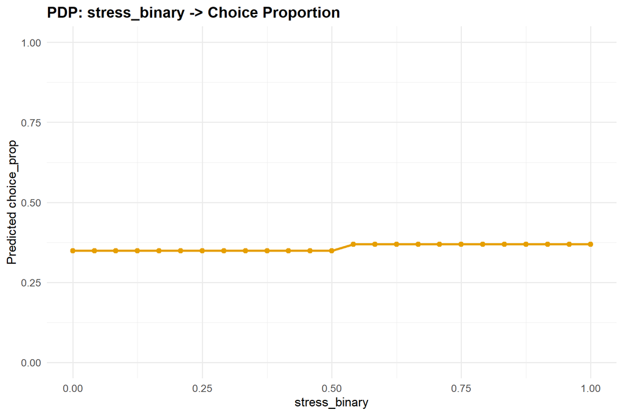

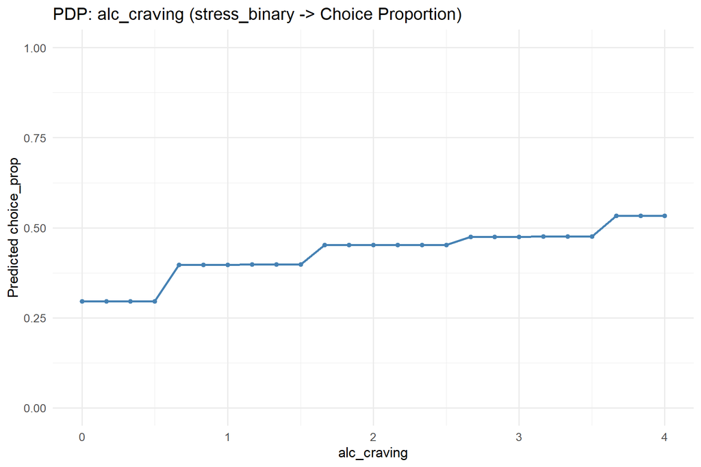

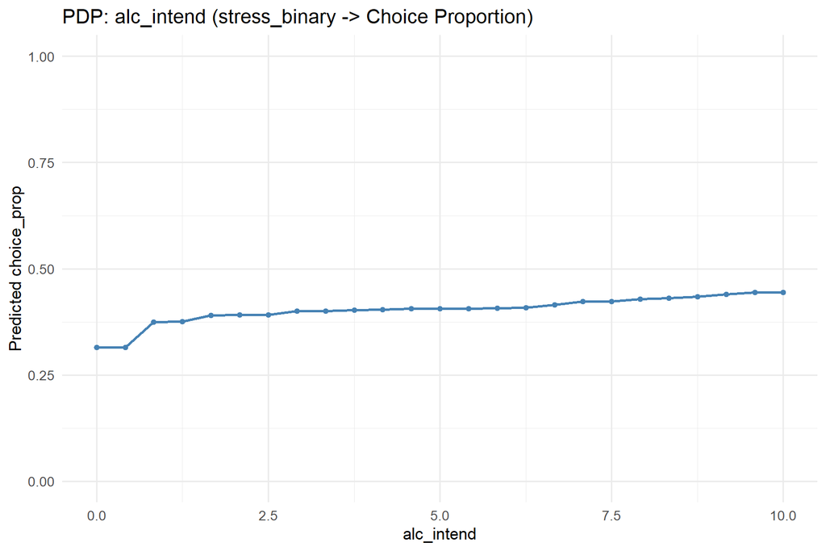

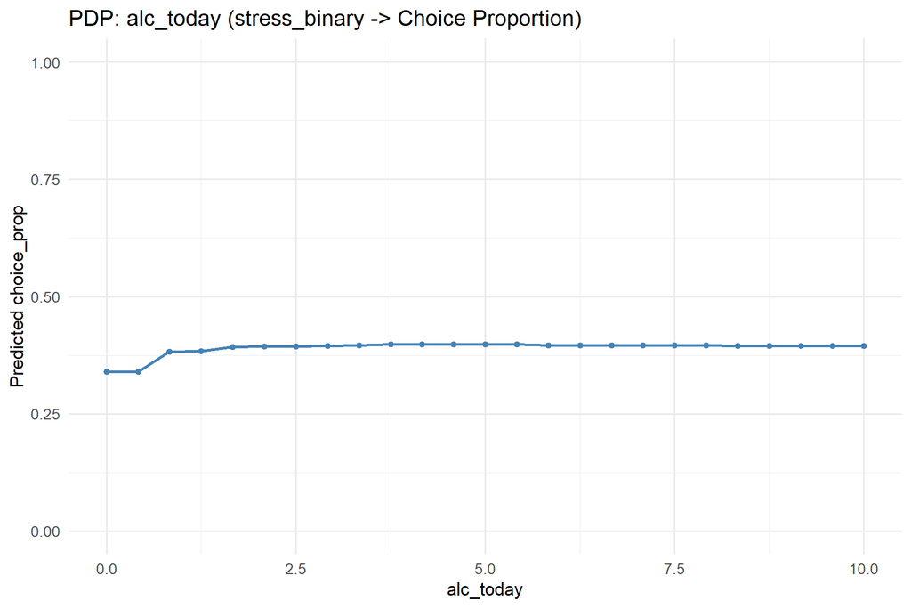

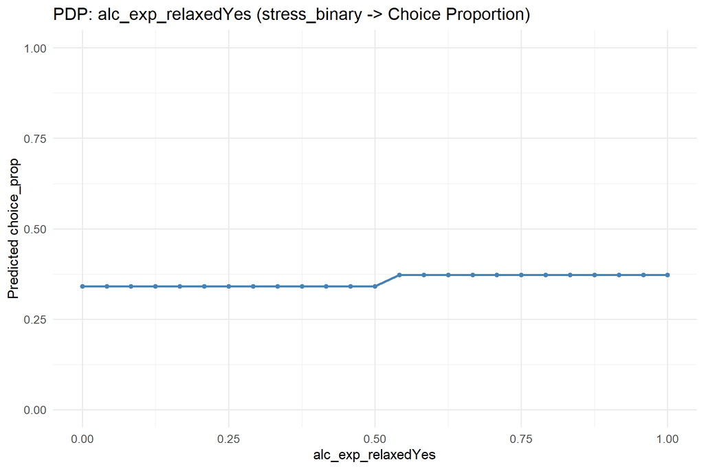

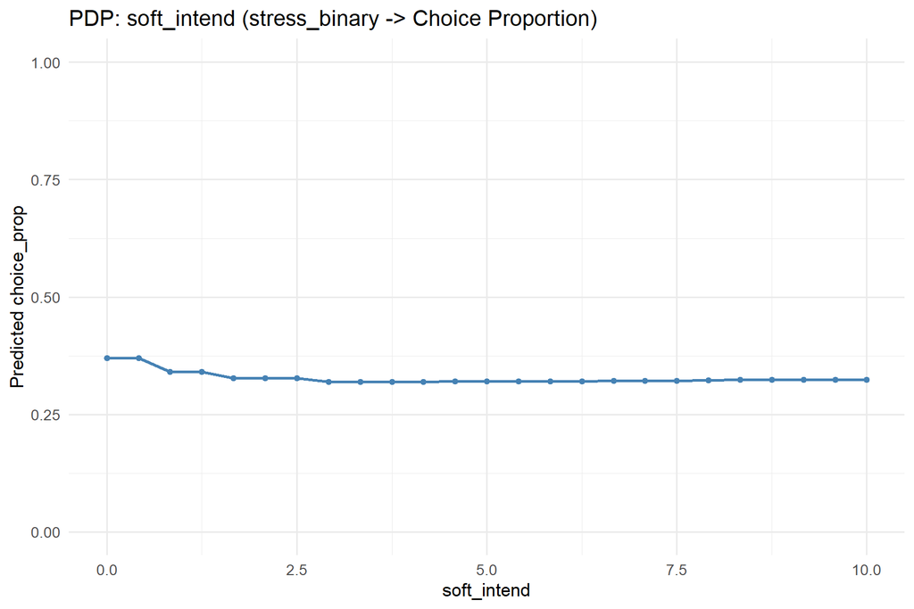

### 2.3.4 Predicted vs. Observed

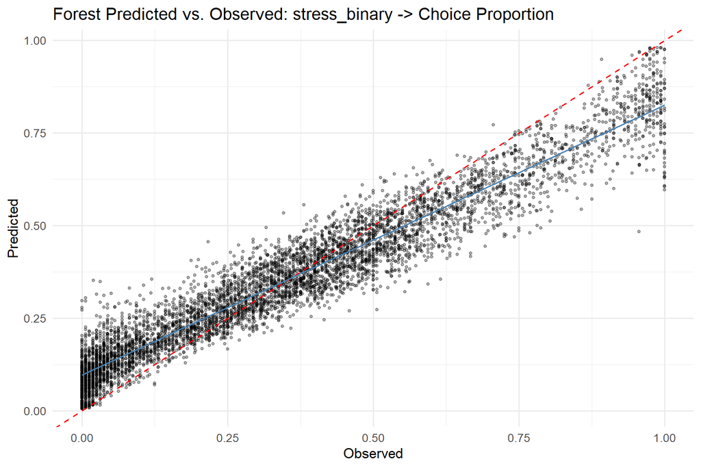

## 2.4 Model Comparison

### 2.4.1 RMSE Comparison (all methods and feature sets)

| Method | Raw | PCA | UMAP |
| --- | --- | --- | --- |
| glmm | 0.2872 | 0.3153 | 0.2896 |
| forest | 0.1930 | 0.2337 | 0.2141 |
| tree | 0.2445 | 0.2600 | 0.2648 |

# 3 Stress State (stress_state)

## 3.1 Dimensionality Reduction

- **PCA components (80% variance, max 5):** 5
- **UMAP components (matching PCA):** 5

### 3.1.1 PCA Component Composition (top 5 correlated variables)

**PC_1**

| Variable | Correlation |
| --- | --- |
| alc_exp_energeticYes | -0.576 |
| alc_exp_better_moodYes | -0.557 |
| alc_exp_sociableYes | -0.547 |
| alc_exp_buzzYes | -0.502 |
| alc_craving | -0.487 |

**PC_2**

| Variable | Correlation |
| --- | --- |
| alc_exp_injuryYes | -0.595 |
| alc_exp_be_rudeYes | -0.593 |
| alc_exp_embarrassedYes | -0.578 |
| alc_exp_nauseous_vomitYes | -0.491 |
| alc_exp_hangoverYes | -0.467 |

**PC_3**

| Variable | Correlation |
| --- | --- |
| locationschool_work | 0.591 |
| alc_today | -0.578 |
| alc_cuenone | 0.569 |
| time_of_dayevening | -0.476 |
| locationhome | -0.459 |

**PC_4**

| Variable | Correlation |
| --- | --- |
| soft_yday | 0.697 |
| soft_today | 0.649 |
| soft_intend | 0.634 |
| soft_craving | 0.489 |
| alc_exp_embarrassedYes | -0.389 |

**PC_5**

| Variable | Correlation |
| --- | --- |
| locationhome | -0.632 |
| social_context_aloneYes | -0.560 |
| social_context_friend_roommateYes | 0.501 |
| social_context_strangerYes | 0.418 |
| locationsomeone_elses_home | 0.372 |

### 3.1.2 UMAP Component Composition (top 5 correlated variables)

**UMAP_1**

| Variable | Correlation |
| --- | --- |
| alc_exp_embarrassedYes | -0.308 |
| alc_exp_be_rudeYes | -0.304 |
| alc_craving | -0.234 |
| alc_intend | -0.164 |
| alc_mot_copingYes | -0.140 |

**UMAP_2**

| Variable | Correlation |
| --- | --- |
| alc_yday | 0.393 |
| alc_intend | 0.201 |
| alc_mot_enhanceYes | 0.131 |
| alc_exp_embarrassedYes | -0.114 |
| alc_exp_be_rudeYes | -0.111 |

**UMAP_3**

| Variable | Correlation |
| --- | --- |
| alc_today | -0.367 |
| alc_yday | -0.343 |
| alc_cuenone | 0.148 |
| social_context_familyYes | -0.131 |
| soft_craving | 0.130 |

**UMAP_4**

| Variable | Correlation |
| --- | --- |
| soft_yday | 0.769 |
| soft_today | 0.658 |
| soft_intend | 0.546 |
| soft_craving | 0.283 |
| alc_exp_be_rudeYes | 0.168 |

**UMAP_5**

| Variable | Correlation |
| --- | --- |
| alc_exp_injuryYes | 0.519 |
| alc_exp_embarrassedYes | 0.389 |
| alc_exp_be_rudeYes | 0.387 |
| alc_exp_nauseous_vomitYes | 0.364 |
| alc_exp_energeticYes | 0.229 |

## 3.2 GLMM Results

### 3.2.1 Raw Features

- **Optimal lambda:** 50 (index 11 of 21)
- **CV RMSE:** 0.2867

**Non-zero coefficients** (focal predictor terms highlighted):

| Term | Estimate | Category |
| --- | --- | --- |
| (Intercept) | 0.2757 | Intercept |
| stress_state | 0.0006 | Focal predictor |
| alc_exp_nauseous_vomitYes | -0.0396 | Covariate main effect |
| alc_cuenone | -0.0274 | Covariate main effect |
| alc_craving | 0.0251 | Covariate main effect |
| alc_exp_relaxedYes | 0.0243 | Covariate main effect |
| alc_mot_enhanceYes | 0.0170 | Covariate main effect |
| time_of_dayevening | 0.0144 | Covariate main effect |
| alc_exp_buzzYes | 0.0122 | Covariate main effect |
| alc_exp_injuryYes | -0.0121 | Covariate main effect |
| alc_exp_better_moodYes | 0.0119 | Covariate main effect |
| alc_intend | 0.0100 | Covariate main effect |
| alc_exp_be_rudeYes | -0.0089 | Covariate main effect |
| alc_today | 0.0074 | Covariate main effect |
| social_context_romantic_partnerYes | 0.0069 | Covariate main effect |
| social_context_otherYes | -0.0068 | Covariate main effect |
| soft_craving | -0.0067 | Covariate main effect |
| soft_intend | -0.0064 | Covariate main effect |
| alc_exp_embarrassedYes | -0.0059 | Covariate main effect |
| social_context_strangerYes | 0.0058 | Covariate main effect |
| social_context_familyYes | -0.0054 | Covariate main effect |
| alc_exp_hangoverYes | -0.0050 | Covariate main effect |
| locationother | 0.0049 | Covariate main effect |
| alc_exp_sociableYes | 0.0032 | Covariate main effect |
| alc_yday | 0.0023 | Covariate main effect |
| soft_yday | -0.0021 | Covariate main effect |
| alc_mot_copingYes | 0.0020 | Covariate main effect |
| social_context_friend_roommateYes | 0.0020 | Covariate main effect |
| locationrestaurant_cafe | 0.0015 | Covariate main effect |
| alc_exp_energeticYes | 0.0014 | Covariate main effect |

[output cut: 51 more lines]

- 17 coefficients penalized to zero.*

#### 3.2.1.1 Predicted vs. Observed

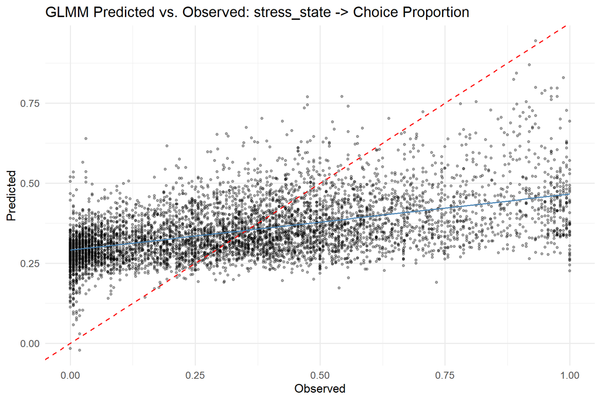

#### 3.2.1.2 Residual Diagnostics

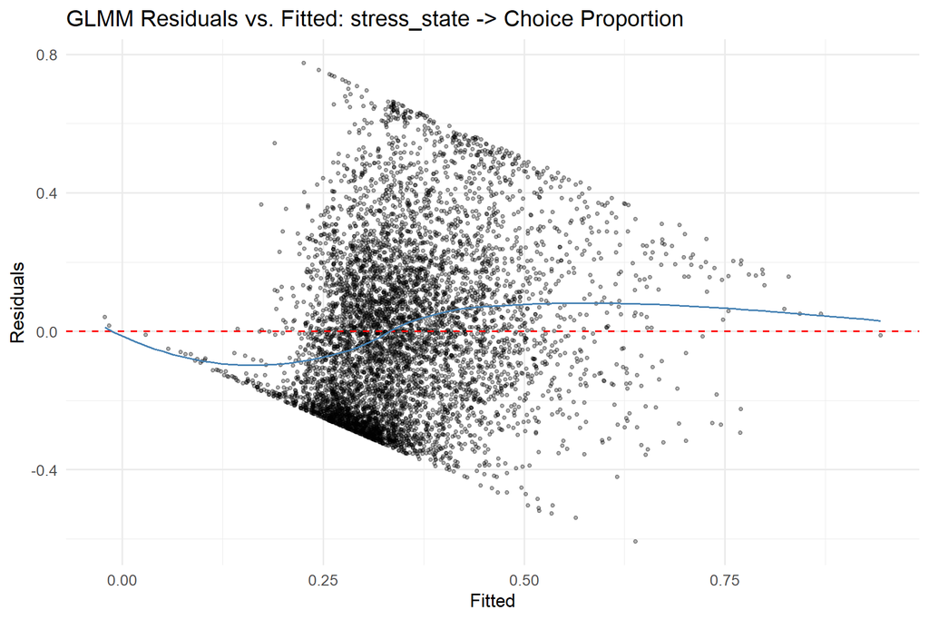

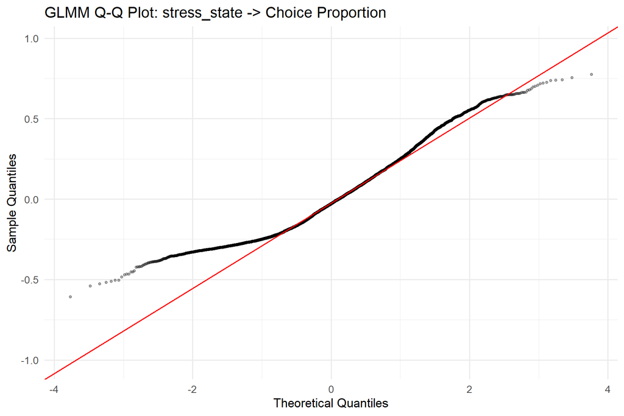

### 3.2.2 PCA Features

- **Optimal lambda:** 90 (index 3 of 21)
- **CV RMSE:** 0.3097

**Non-zero coefficients:**

| Term | Estimate |
| --- | --- |
| (Intercept) | 0.3361 |
| PC_1 | -0.0264 |
| PC_2 | 0.0556 |
| PC_3 | -0.0506 |
| stress_state | 0.0155 |
| PC_1:stress_state | -0.0056 |
| PC_2:stress_state | 0.0024 |
| PC_3:stress_state | -0.0027 |
| PC_5:stress_state | -0.0056 |

- 3 coefficients penalized to zero.*

### 3.2.3 UMAP Features

- **Optimal lambda:** 100 (index 1 of 21)
- **CV RMSE:** 0.2841

**Non-zero coefficients:**

| Term | Estimate |
| --- | --- |
| (Intercept) | 0.3372 |
| UMAP_1 | -0.0039 |
| UMAP_2 | 0.0135 |
| UMAP_3 | -0.0097 |
| UMAP_4 | -0.0226 |
| stress_state | 0.0166 |
| UMAP_3:stress_state | -0.0034 |
| UMAP_4:stress_state | -0.0002 |
| UMAP_5:stress_state | -0.0038 |

- 3 coefficients penalized to zero.*

## 3.3 Random Forest Results (Raw)

### 3.3.1 Tuning Summary

- **mtry:** 16
- **min.node.size:** 2
- **sample.fraction:** 0.808
- **CV RMSE:** 0.1918

### 3.3.2 Variable Importance (Permutation)

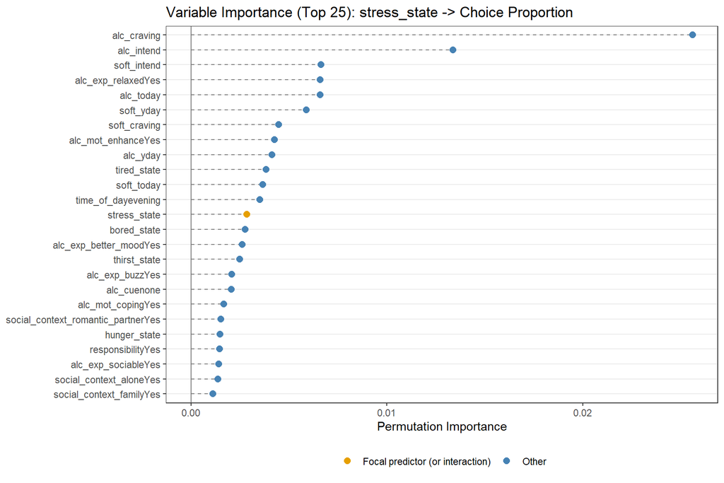

**Full importance ranking:**

| Variable | Importance |
| --- | --- |
| alc_craving | 0.025618 |
| alc_intend | 0.013367 |
| soft_intend | 0.006623 |
| alc_exp_relaxedYes | 0.006600 |
| alc_today | 0.006580 |
| soft_yday | 0.005876 |
| soft_craving | 0.004463 |
| alc_mot_enhanceYes | 0.004267 |
| alc_yday | 0.004133 |
| tired_state | 0.003835 |
| soft_today | 0.003649 |
| time_of_dayevening | 0.003500 |
| stress_state | 0.002854 |
| bored_state | 0.002758 |
| alc_exp_better_moodYes | 0.002616 |
| thirst_state | 0.002470 |
| alc_exp_buzzYes | 0.002083 |
| alc_cuenone | 0.002049 |
| alc_mot_copingYes | 0.001673 |
| social_context_romantic_partnerYes | 0.001513 |
| hunger_state | 0.001485 |
| responsibilityYes | 0.001448 |
| alc_exp_sociableYes | 0.001411 |
| social_context_aloneYes | 0.001377 |
| social_context_familyYes | 0.001118 |
| alc_exp_embarrassedYes | 0.000845 |
| alc_exp_hangoverYes | 0.000825 |
| locationhome | 0.000710 |
| locationschool_work | 0.000648 |
| alc_exp_be_rudeYes | 0.000555 |
| alc_exp_nauseous_vomitYes | 0.000506 |
| alc_exp_energeticYes | 0.000505 |
| alc_mot_socialYes | 0.000380 |
| alc_exp_injuryYes | 0.000229 |
| locationother | 0.000202 |
| social_context_friend_roommateYes | 0.000128 |
| alc_cueindirectly_visible | 0.000078 |
| day_of_weekSat | 0.000067 |
| locationsomeone_elses_home | 0.000065 |
| social_context_strangerYes | 0.000053 |
| locationoutdoors | 0.000029 |
| social_context_coworker_classmateYes | 0.000011 |
| social_context_otherYes | 0.000010 |
| locationrestaurant_cafe | 0.000010 |
| day_of_weekSun | 0.000001 |
| day_of_weekThu | -0.000067 |
| day_of_weekTue | -0.000071 |
| day_of_weekWed | -0.000087 |
| day_of_weekMon | -0.000090 |

### 3.3.3 Partial Dependence Plots

PDP for the focal predictor and the top 5 most important non-interaction covariates.

#### 3.3.3.1 Focal Predictor: stress_state

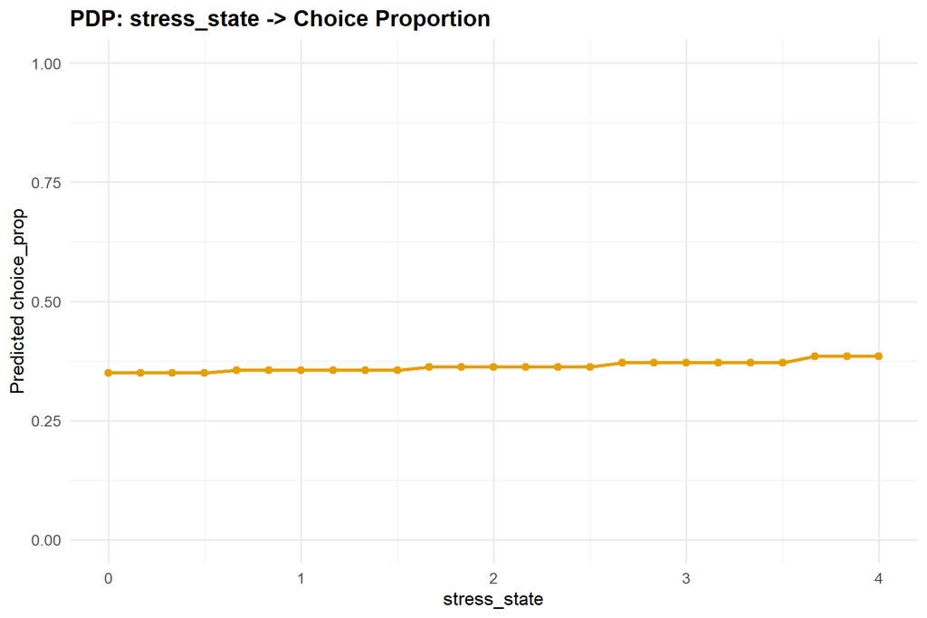

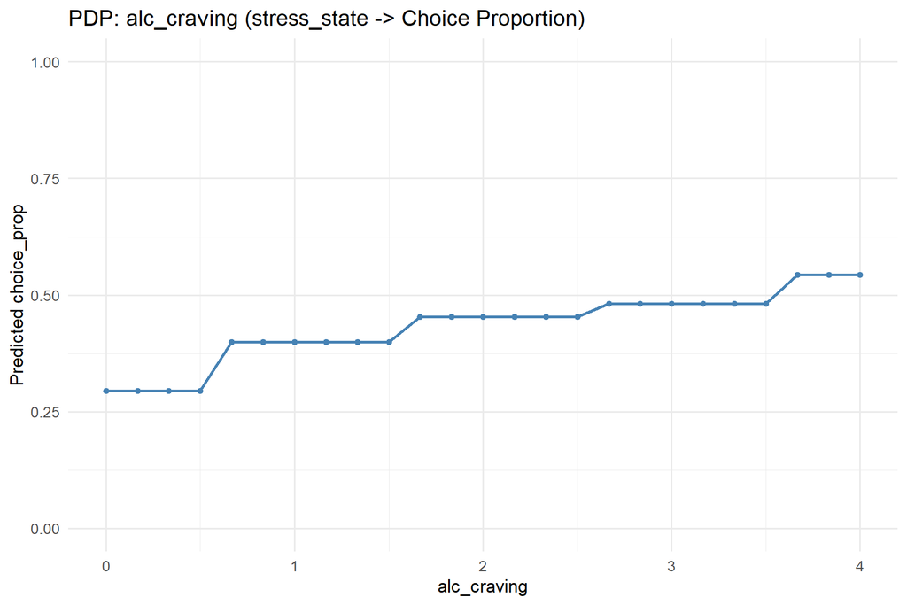

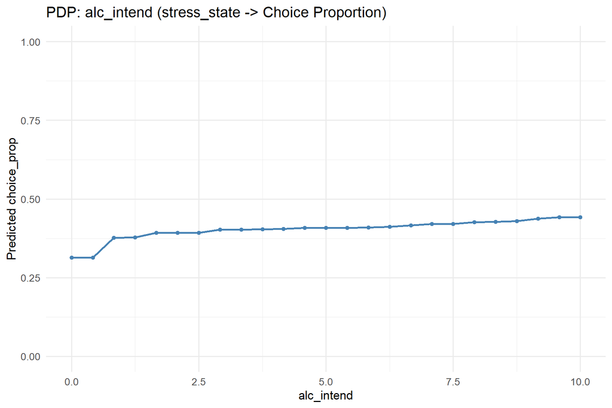

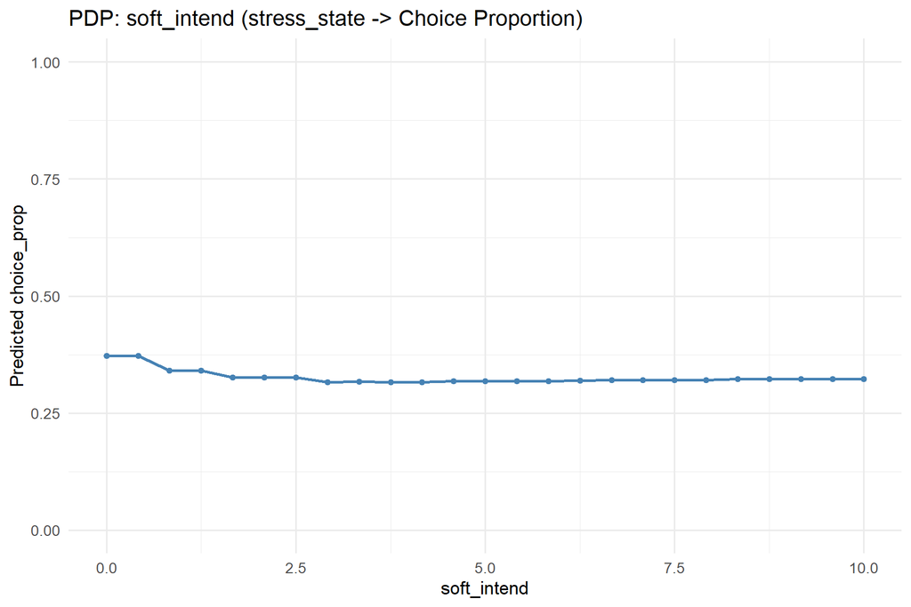

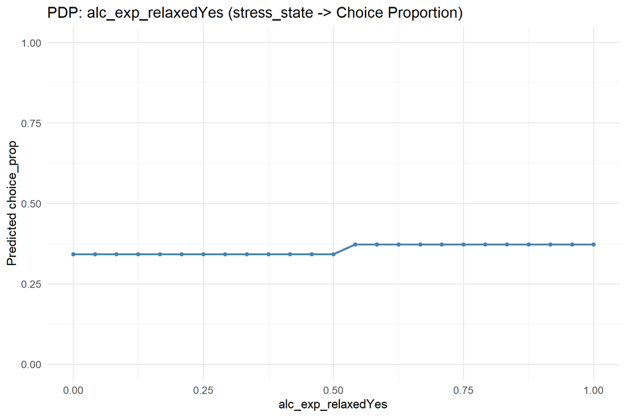

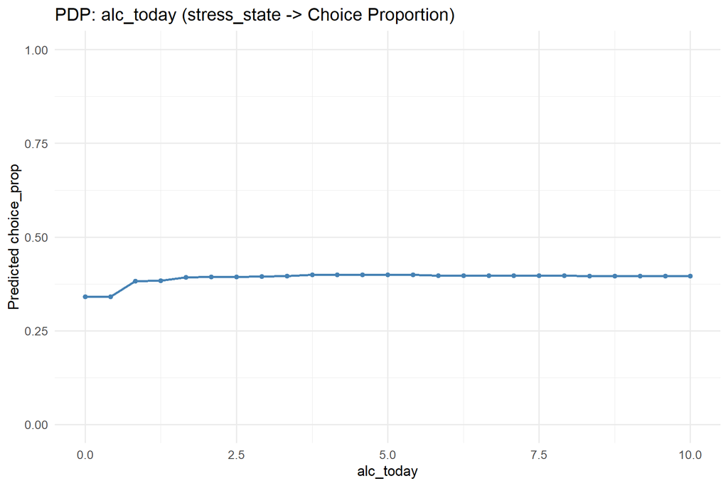

### 3.3.4 Predicted vs. Observed

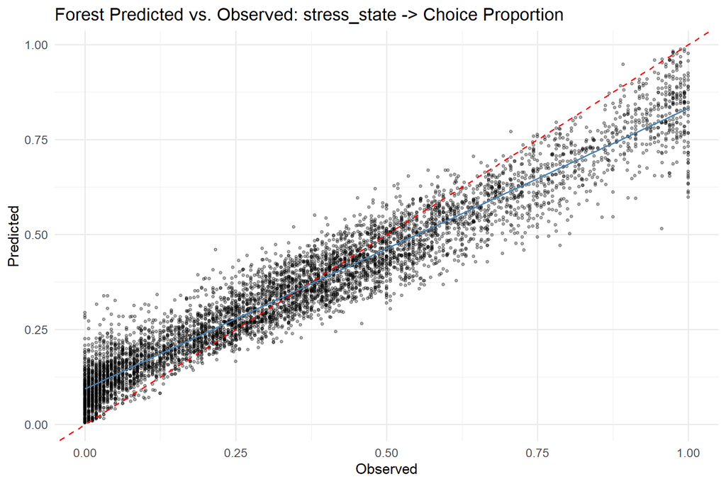

## 3.4 Model Comparison

### 3.4.1 RMSE Comparison (all methods and feature sets)

| Method | Raw | PCA | UMAP |
| --- | --- | --- | --- |
| glmm | 0.2867 | 0.3097 | 0.2841 |
| forest | 0.1918 | 0.2332 | 0.2130 |
| tree | 0.2466 | 0.2630 | 0.2629 |

# 4 Negative Affect State (NA_state)

## 4.1 Dimensionality Reduction

- **PCA components (80% variance, max 5):** 5
- **UMAP components (matching PCA):** 5

### 4.1.1 PCA Component Composition (top 5 correlated variables)

**PC_1**

| Variable | Correlation |
| --- | --- |
| alc_exp_energeticYes | -0.576 |
| alc_exp_better_moodYes | -0.557 |
| alc_exp_sociableYes | -0.547 |
| alc_exp_buzzYes | -0.502 |
| alc_craving | -0.487 |

**PC_2**

| Variable | Correlation |
| --- | --- |
| alc_exp_injuryYes | -0.596 |
| alc_exp_be_rudeYes | -0.594 |
| alc_exp_embarrassedYes | -0.579 |
| alc_exp_nauseous_vomitYes | -0.491 |
| alc_exp_hangoverYes | -0.468 |

**PC_3**

| Variable | Correlation |
| --- | --- |
| locationschool_work | 0.591 |
| alc_today | -0.578 |
| alc_cuenone | 0.569 |
| time_of_dayevening | -0.476 |
| locationhome | -0.457 |

**PC_4**

| Variable | Correlation |
| --- | --- |
| soft_yday | 0.700 |
| soft_today | 0.650 |
| soft_intend | 0.635 |
| soft_craving | 0.488 |
| alc_exp_embarrassedYes | -0.388 |

**PC_5**

| Variable | Correlation |
| --- | --- |
| locationhome | -0.634 |
| social_context_aloneYes | -0.558 |
| social_context_friend_roommateYes | 0.499 |
| social_context_strangerYes | 0.418 |
| locationsomeone_elses_home | 0.371 |

### 4.1.2 UMAP Component Composition (top 5 correlated variables)

**UMAP_1**

| Variable | Correlation |
| --- | --- |
| alc_exp_embarrassedYes | -0.315 |
| alc_exp_be_rudeYes | -0.311 |
| alc_craving | -0.241 |
| alc_intend | -0.187 |
| alc_mot_copingYes | -0.145 |

**UMAP_2**

| Variable | Correlation |
| --- | --- |
| alc_yday | 0.359 |
| alc_intend | 0.162 |
| alc_exp_embarrassedYes | -0.154 |
| alc_exp_be_rudeYes | -0.152 |
| alc_mot_enhanceYes | 0.121 |

**UMAP_3**

| Variable | Correlation |
| --- | --- |
| alc_yday | -0.434 |
| alc_today | -0.399 |
| alc_intend | -0.191 |
| alc_cuenone | 0.179 |
| social_context_familyYes | -0.133 |

**UMAP_4**

| Variable | Correlation |
| --- | --- |
| soft_yday | 0.768 |
| soft_today | 0.659 |
| soft_intend | 0.548 |
| soft_craving | 0.285 |
| alc_exp_injuryYes | 0.153 |

**UMAP_5**

| Variable | Correlation |
| --- | --- |
| alc_exp_injuryYes | 0.514 |
| alc_exp_embarrassedYes | 0.380 |
| alc_exp_be_rudeYes | 0.379 |
| alc_exp_nauseous_vomitYes | 0.358 |
| alc_exp_energeticYes | 0.232 |

## 4.2 GLMM Results

### 4.2.1 Raw Features

- **Optimal lambda:** 30 (index 15 of 21)
- **CV RMSE:** 0.2885

**Non-zero coefficients** (focal predictor terms highlighted):

| Term | Estimate | Category |
| --- | --- | --- |
| (Intercept) | 0.2742 | Intercept |
| NA_state | 0.0005 | Focal predictor |
| alc_exp_nauseous_vomitYes | -0.0426 | Covariate main effect |
| alc_cuenone | -0.0289 | Covariate main effect |
| alc_exp_relaxedYes | 0.0260 | Covariate main effect |
| alc_craving | 0.0258 | Covariate main effect |
| alc_mot_enhanceYes | 0.0186 | Covariate main effect |
| social_context_otherYes | -0.0185 | Covariate main effect |
| alc_exp_injuryYes | -0.0166 | Covariate main effect |
| time_of_dayevening | 0.0163 | Covariate main effect |
| alc_exp_better_moodYes | 0.0140 | Covariate main effect |
| alc_exp_buzzYes | 0.0139 | Covariate main effect |
| social_context_strangerYes | 0.0118 | Covariate main effect |
| alc_exp_be_rudeYes | -0.0116 | Covariate main effect |
| alc_intend | 0.0104 | Covariate main effect |
| locationrestaurant_cafe | 0.0100 | Covariate main effect |
| social_context_romantic_partnerYes | 0.0092 | Covariate main effect |
| locationother | 0.0091 | Covariate main effect |
| alc_exp_embarrassedYes | -0.0090 | Covariate main effect |
| alc_today | 0.0078 | Covariate main effect |
| social_context_familyYes | -0.0077 | Covariate main effect |
| soft_craving | -0.0075 | Covariate main effect |
| alc_exp_hangoverYes | -0.0075 | Covariate main effect |
| soft_intend | -0.0070 | Covariate main effect |
| alc_exp_sociableYes | 0.0055 | Covariate main effect |
| social_context_friend_roommateYes | 0.0053 | Covariate main effect |
| social_context_coworker_classmateYes | -0.0053 | Covariate main effect |
| alc_exp_energeticYes | 0.0049 | Covariate main effect |
| alc_mot_copingYes | 0.0048 | Covariate main effect |
| alc_yday | 0.0026 | Covariate main effect |

[output cut: 54 more lines]

- 14 coefficients penalized to zero.*

#### 4.2.1.1 Predicted vs. Observed

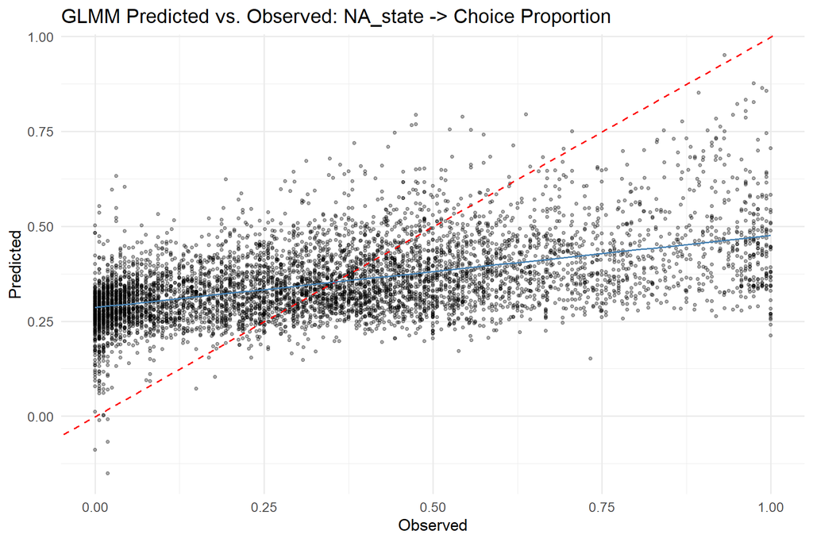

#### 4.2.1.2 Residual Diagnostics

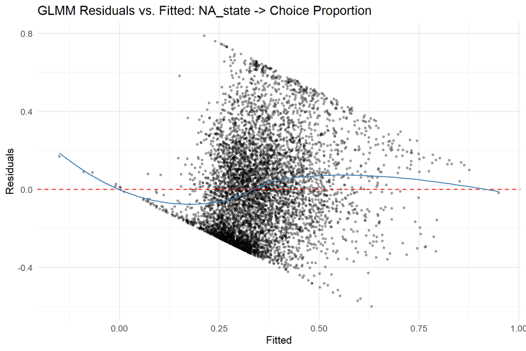

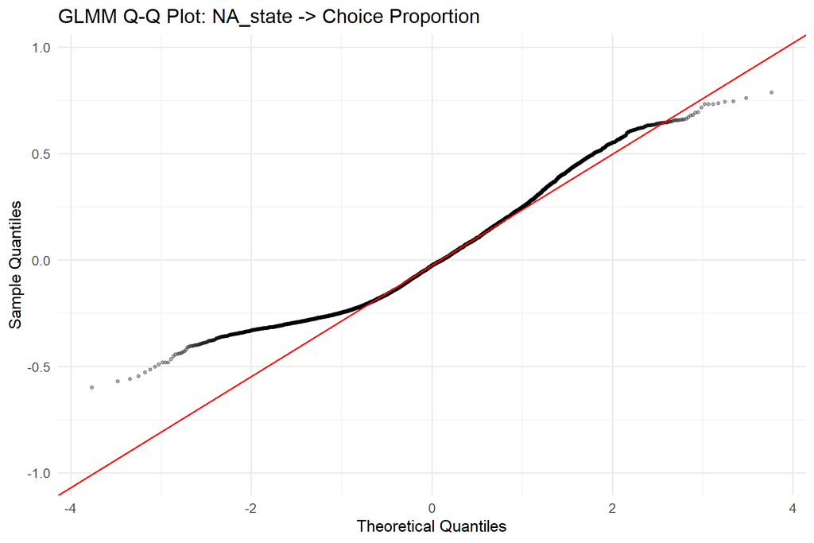

### 4.2.2 PCA Features

- **Optimal lambda:** 85 (index 4 of 21)
- **CV RMSE:** 0.307

**Non-zero coefficients:**

| Term | Estimate |
| --- | --- |
| (Intercept) | 0.3409 |
| PC_1 | -0.0279 |
| PC_2 | 0.0574 |
| PC_3 | -0.0519 |
| NA_state | 0.0105 |
| PC_1:NA_state | -0.0043 |
| PC_2:NA_state | 0.0003 |
| PC_3:NA_state | -0.0027 |
| PC_5:NA_state | -0.0074 |

- 3 coefficients penalized to zero.*

### 4.2.3 UMAP Features

- **Optimal lambda:** 90 (index 3 of 21)
- **CV RMSE:** 0.2814

**Non-zero coefficients:**

| Term | Estimate |
| --- | --- |
| (Intercept) | 0.3391 |
| UMAP_1 | -0.0046 |
| UMAP_2 | 0.0095 |
| UMAP_3 | -0.0175 |
| UMAP_4 | -0.0253 |
| NA_state | 0.0149 |
| UMAP_1:NA_state | -0.0012 |
| UMAP_2:NA_state | 0.0041 |
| UMAP_3:NA_state | -0.0091 |
| UMAP_4:NA_state | -0.0080 |
| UMAP_5:NA_state | -0.0038 |

- 1 coefficients penalized to zero.*

## 4.3 Random Forest Results (Raw)

### 4.3.1 Tuning Summary

- **mtry:** 12
- **min.node.size:** 3
- **sample.fraction:** 0.804
- **CV RMSE:** 0.1919

### 4.3.2 Variable Importance (Permutation)

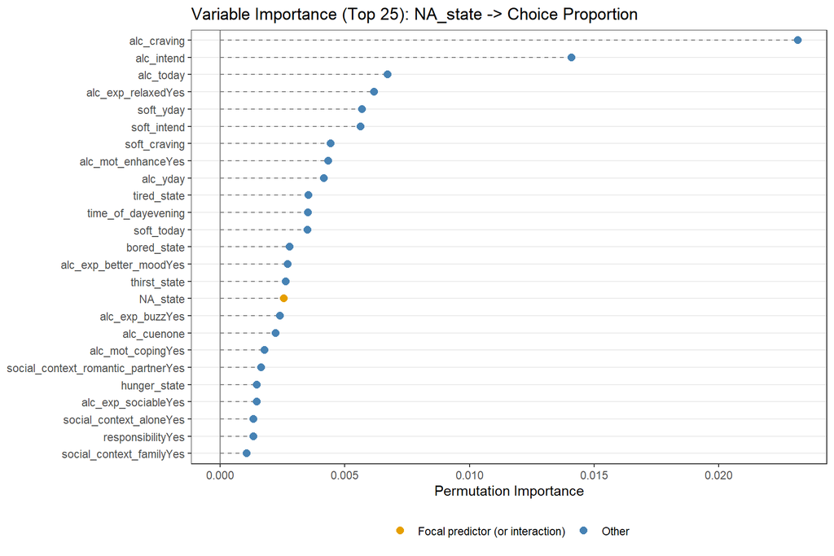

**Full importance ranking:**

| Variable | Importance |
| --- | --- |
| alc_craving | 0.023173 |
| alc_intend | 0.014100 |
| alc_today | 0.006718 |
| alc_exp_relaxedYes | 0.006166 |
| soft_yday | 0.005695 |
| soft_intend | 0.005627 |
| soft_craving | 0.004422 |
| alc_mot_enhanceYes | 0.004329 |
| alc_yday | 0.004153 |
| tired_state | 0.003548 |
| time_of_dayevening | 0.003520 |
| soft_today | 0.003500 |
| bored_state | 0.002778 |
| alc_exp_better_moodYes | 0.002700 |
| thirst_state | 0.002629 |
| NA_state | 0.002563 |
| alc_exp_buzzYes | 0.002403 |
| alc_cuenone | 0.002229 |
| alc_mot_copingYes | 0.001776 |
| social_context_romantic_partnerYes | 0.001638 |
| hunger_state | 0.001476 |
| alc_exp_sociableYes | 0.001475 |
| social_context_aloneYes | 0.001339 |
| responsibilityYes | 0.001326 |
| social_context_familyYes | 0.001054 |
| alc_exp_embarrassedYes | 0.000886 |
| locationhome | 0.000749 |
| alc_exp_hangoverYes | 0.000720 |
| locationschool_work | 0.000655 |
| alc_exp_nauseous_vomitYes | 0.000617 |
| alc_exp_energeticYes | 0.000577 |
| alc_exp_be_rudeYes | 0.000543 |
| alc_mot_socialYes | 0.000477 |
| alc_exp_injuryYes | 0.000249 |
| locationother | 0.000174 |
| social_context_friend_roommateYes | 0.000103 |
| social_context_coworker_classmateYes | 0.000083 |
| alc_cueindirectly_visible | 0.000070 |
| locationsomeone_elses_home | 0.000066 |
| social_context_strangerYes | 0.000053 |
| locationoutdoors | 0.000032 |
| social_context_otherYes | 0.000017 |
| day_of_weekSun | 0.000016 |
| locationrestaurant_cafe | 0.000004 |
| day_of_weekSat | -0.000007 |
| day_of_weekWed | -0.000021 |
| day_of_weekMon | -0.000058 |
| day_of_weekTue | -0.000112 |
| day_of_weekThu | -0.000117 |

### 4.3.3 Partial Dependence Plots

PDP for the focal predictor and the top 5 most important non-interaction covariates.

#### 4.3.3.1 Focal Predictor: NA_state

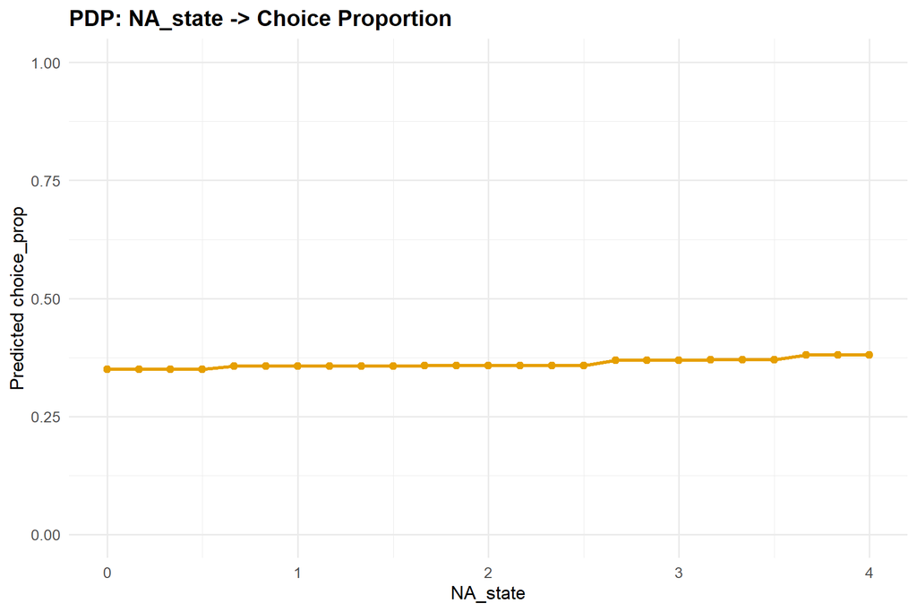

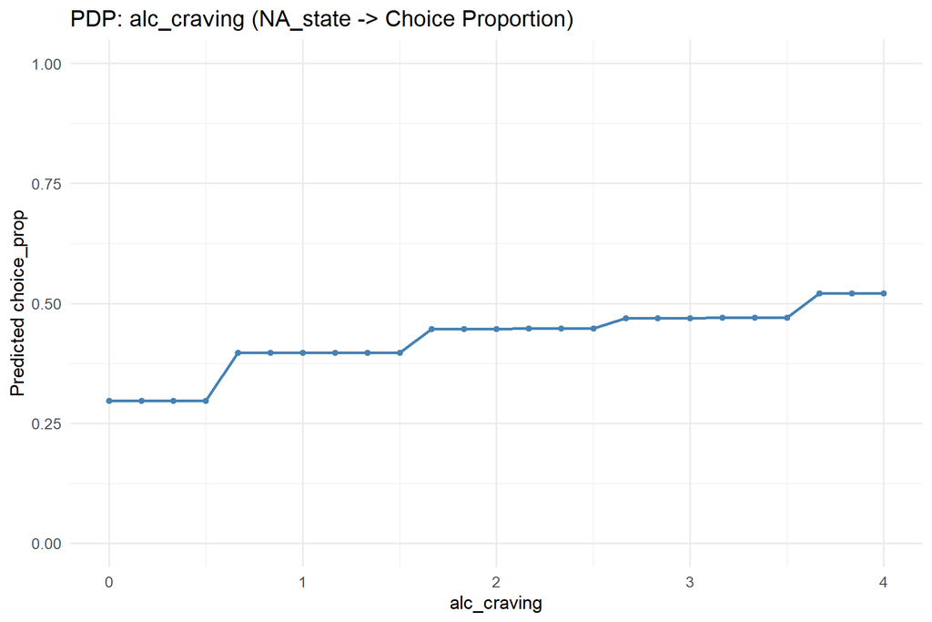

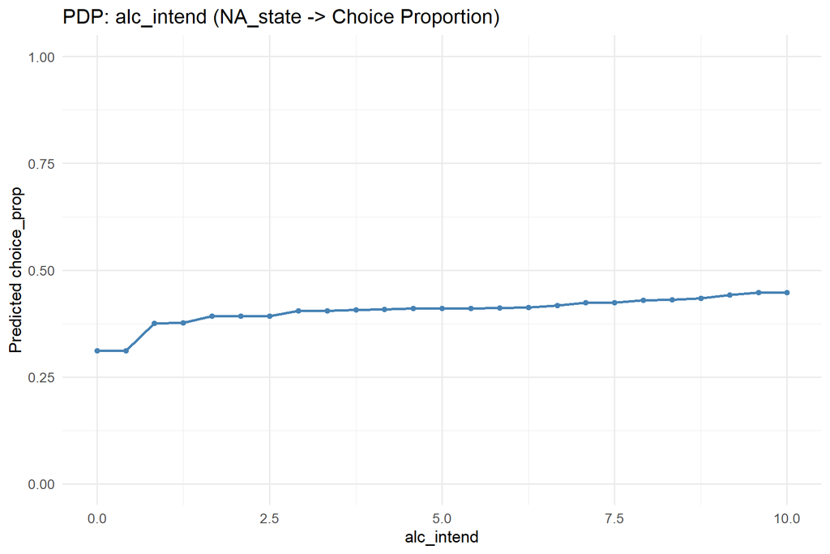

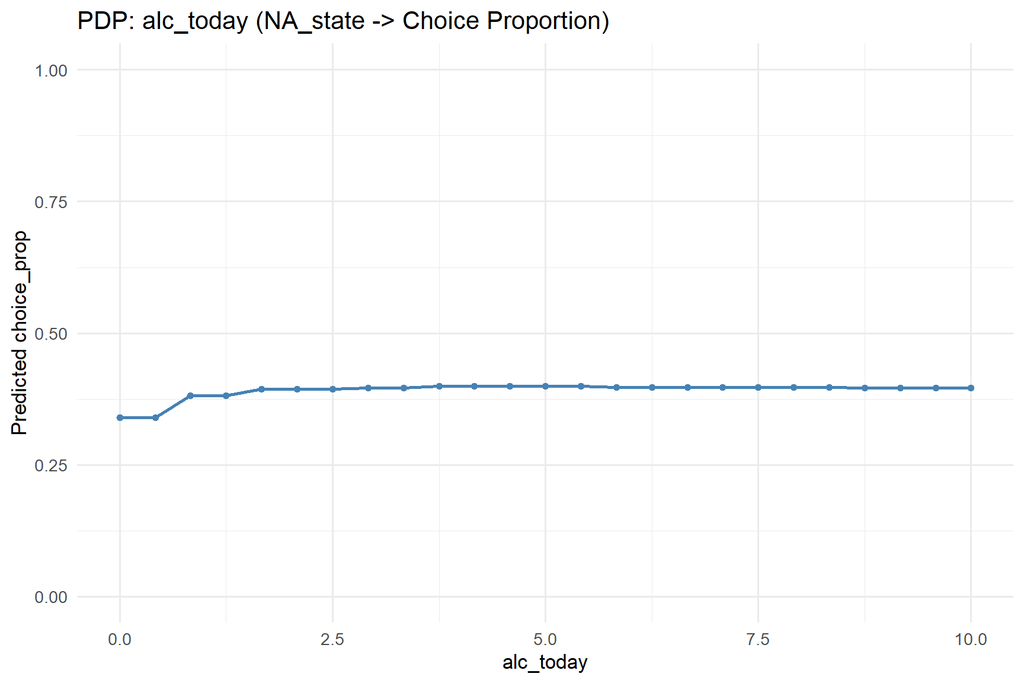

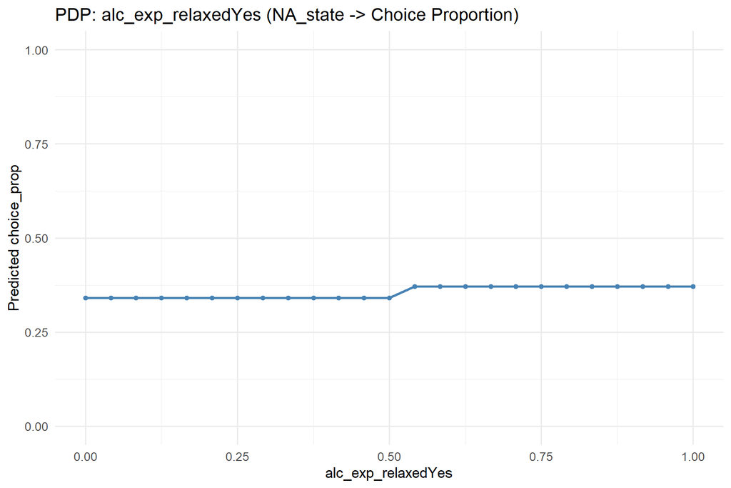

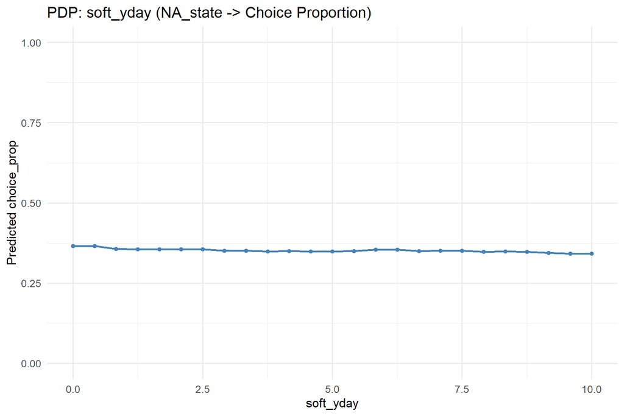